# Using Yelp Data to Predict Local Housing Prices

Lawrence

5/5/2018

## The Data

For this project, we use data provided by Yelp for the Yelp Dataset challenge, which can be found in JSON format from this website:

https://www.yelp.com/dataset/challenge

Documentation describing the variables and information contained in each json file comprising the yelp challenge dataset can be found here:

https://www.yelp.com/dataset/documentation/json

We then merge it with Zillow data on rental values across the United States by postal code. The Zillow rental value dataset can be downloaded from this website:

https://www.zillow.com/research/data/

## Setting the Working Directory and loading in required packages

## Importing the data

First, we import the Yelp checkin data and flatten it.

```r
# Stream in Checkin Data
yelp_checkin <- as.data.frame(jsonlite::stream_in(file("dataset/checkin.json")), flatten = TRUE)
# Flatten Checkin Data
renquote <- function(l) if (is.list(l)) lapply(l, renquote) else enquote(l)
yelp_checkin_flat <- as.data.frame(lapply(unlist(renquote(yelp_checkin)), eval))
```

## Reshaping the data

We clean the time period variable names by collapsing to long and using string functions to isolate day of the week name in string.

```r
# Convert from wide to long
yelp_checkin_flat_long <- reshape(yelp_checkin_flat, varying = list(names(yelp_checkin_flat[1:168])), times = names(yelp_checkin_flat[1:168]), idvar = 'business_id', v.names = 'checkin' , direction = 'long')

# Elimminate punctuation and digits
yelp_checkin_flat_long$time <- str_replace(yelp_checkin_flat_long$time, "time.", "")
yelp_checkin_flat_long$time <- gsub('[[:digit:]]+', '', yelp_checkin_flat_long$time)

# Isolate name of weekday
yelp_checkin_flat_long$time = substr(yelp_checkin_flat_long$time,1,nchar(yelp_checkin_flat_long$time)-2)
```

Here, we will collapse the data, reshape it from long to wide, then merge them together.

```r
# Aggregate checkin by business and time period to get checkin average and totalby business for each day of the week.
yelp_checkin_collapse_mean <- as.data.frame(aggregate(checkin ~ business_id + time, yelp_checkin_flat_long , mean))
yelp_checkin_collapse_sum <- as.data.frame(aggregate(checkin ~ business_id + time, yelp_checkin_flat_long , sum))

# Convert from long to wide
yelp_checkin_wide_mean <- spread(yelp_checkin_collapse_mean, key = time, value = checkin)
yelp_checkin_wide_sum <- spread(yelp_checkin_collapse_sum, key = time, value = checkin)

# Merge averages and totals
yelp_checkin_wide <- inner_join(yelp_checkin_wide_mean, yelp_checkin_wide_sum, by='business_id', match='all')
colnames(yelp_checkin_wide) <- c("business_id", "Friday_ave", "Monday_ave", "Saturday_ave", "Sunday_ave", "Thursday_ave", "Tuesday_ave", "Wednesday_ave", "Friday_total", "Monday_total", "Saturday_total", "Sunday_total", "Thursday_total", "Tuesday_total", "Wednesday_total")
```

## Loading in business dataset to merge with check in data and aggregate by zip code. Then we eliminate useless columns and merge.

```r
# Import business dataset
yelp_business <- fromJSON(sprintf("[%s]", paste(readLines("dataset/business.json"), collapse=",")), simplifyDataFrame=TRUE, flatten=TRUE)

# Merge checkin data with business data by business
checkinbiz <- inner_join(yelp_business, yelp_checkin_wide, by=c('business_id'), match='all')

# Eliminate unneeded columns
checkinbiz <- checkinbiz[-c(2:6, 8:101)]

# Collapse checkin data by zipcode to get total and average checkins each weekday for each zipcode
checkinzipmean <- as.data.frame(aggregate(. ~ postal_code, checkinbiz[2:9], mean))
checkinzipsum <- as.data.frame(aggregate(. ~ postal_code, checkinbiz[c(2, 10:16)], sum))

checkinfull <- inner_join(checkinzipmean, checkinzipsum, by=c('postal_code'), match='all')
```

## Importing the Yelp Review Data

Because of the large size of the yelp review JSON file, The Yelp Review dataset was collapsed to the zipcode level through merging, aggregation, and collapsing within the google cloud platform.

```r
# Import data
yelp_review_long <- read.csv("yelplongPC_updated2.csv", header = T, na.strings=c("NA"))

# Check missingness
sapply(yelp_review_long, function(x) sum(is.na(x)))
```

```
##                    X          postal_code            YearMonth
##                    0                    0                    0
## Number_of_businesses    Number_of_reviews              starsav
##                    0                    0                    0
##              starssd             usefulav              funnyav
##               168953                    0                    0
##               coolav             bizstars           bizstarssd
##                    0                    0               168953
##          bizrevcount             bizrevav           is_openave
##                    0                    0                    0
```

```r
# Check how many unique zipcodes
length(unique(yelp_review_long$postal_code))
```

```
## [1] 15890
```

```r
# Convert YearMonth from character to ym class
yelp_review_long$YearMonth <- as.yearmon(yelp_review_long$YearMonth)
```

## Zillow data

Here, we read in the Zillow data that has information on all rental values across the US and Canada. We will rename the RegionName variable to “postal_code” then convert the data from wide to long in order to merge it with the Yelp dataset. We will change the “time” variable to a date class, and finally we cut the Zillow data to match the dates of the Yelp data (while Zillow data goes back to the 1990s, Yelp business and review data only go back to 2010).

```r
# Import data
zillow <- read_csv("zecon/Zip_Zri_AllHomesPlusMultifamily.csv", col_names = TRUE)

# Reformat to prepare for merge with Yelp dataset.
names (zillow)[2] <- "postal_code"
zillow <- as.data.frame(zillow)
zillow_long <- reshape(zillow, varying = list(names(zillow[8:95])), times = names(zillow[8:95]), idvar = 'postal_code', v.names = 'rentprice' , direction = 'long')

sapply(zillow_long, function(x) sum(is.na(x)))
```

```
##    RegionID postal_code        City       State       Metro  CountyName
##           0           0           0           0      113960           0
##    SizeRank        time   rentprice
##           0           0       28354
```

```r
zillow_long$time<- as.Date(strptime(paste(1, zillow_long$time),"%d %Y-%m"))

zillow_long <- zillow_long[zillow_long$time >= "2010-11-01" & zillow_long$time <= "2017-12-31",]

zillow_long$month <- match(months(zillow_long$time), month.name)
zillow_long$year <- format(zillow_long$time,format="%Y")
zillow_long$YearMonth <- as.yearmon(paste(zillow_long$year, zillow_long$month), "%Y %m")
names(zillow_long)
```

```
##  [1] "RegionID"    "postal_code" "City"        "State"       "Metro"
##  [6] "CountyName"  "SizeRank"    "time"        "rentprice"   "month"
## [11] "year"        "YearMonth"
```

Notice that there are 28,354 missing values. We will later attempt to recitfy this through imputation.

## Merging all datasets

Here, we create the official merged dataset from which we conduct the analysis portion

```r
# Merge Checkin with Yelp
yelp_review_long <- left_join(yelp_review_long, checkinfull, by=c('postal_code'), match='all')

# Merge Zillow with Yelp
Full_data_long <- inner_join(yelp_review_long, zillow_long, by=c('postal_code', 'YearMonth'), match='all')
length(unique(Full_data_long$postal_code))
```

```
## [1] 564
```

```r
sapply(Full_data_long, function(x) sum(is.na(x)))
```

```
##                    X          postal_code            YearMonth
##                    0                    0                    0
## Number_of_businesses    Number_of_reviews              starsav
##                    0                    0                    0
##              starssd             usefulav              funnyav
##                 2977                    0                    0
##               coolav             bizstars           bizstarssd
##                    0                    0                 2977
##          bizrevcount             bizrevav           is_openave
##                    0                    0                    0
##           Friday_ave           Monday_ave         Saturday_ave
##                 1337                 1337                 1337
##           Sunday_ave         Thursday_ave          Tuesday_ave
##                 1337                 1337                 1337
##        Wednesday_ave         Friday_total         Monday_total
##                 1337                 1337                 1337
##       Saturday_total         Sunday_total       Thursday_total
##                 1337                 1337                 1337
##        Tuesday_total      Wednesday_total             RegionID
##                 1337                 1337                    0
##                 City                State                Metro
##                    0                    0                   64
##           CountyName             SizeRank                 time
##                    0                    0                    0
##            rentprice                month                 year
##                  580                    0                    0
```

The final frame consists of 37492 observations and 39 variables.

## Explortatory Data Analysis

Here is where we conduct the official analysis portion of the project

```r
# First, we subset business based on eventual merging with Zillow
Full <- unique(Full_data_long$postal_code)
business_zillow <- dplyr::filter(yelp_business, postal_code %in% Full)

# Assessing the count of states
Full_data_long$State <- Full_data_long$State %>% as.factor
Full_data_long$State %>% summary
```

```
##    AR    AZ    CA    FL    GA    IL    IN    KY    LA    MD    MI    MO
##    22 10234   242     4    17   925    15    44   394     6     3     8
##    MS    NC    NJ    NM    NV    NY    OH    OK    PA    SC    TX    VA
##     4  4088     7     3  4981    75  7301     3  6510   405    17     6
##    VT    WI
##     7  2171
```

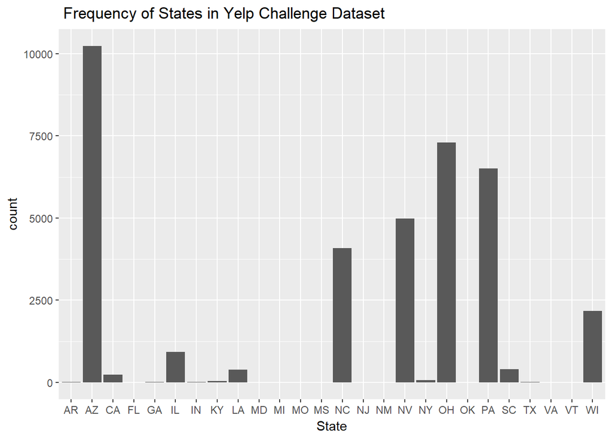

```r
ggplot(Full_data_long, aes(State)) + geom_bar() + labs(title= " Frequency of States in Yelp Challenge Dataset")
```

The states most represented in the dataset are Arizona, Ohio, Pennsylvania, Nevada, North Carolina, Wisconsin, and Illinois.

```r
Full_data_long$City <- Full_data_long$City %>% as.factor
Full_data_long$City %>% summary
```

```
##           Phoenix         Las Vegas         Charlotte        Pittsburgh
##              3918              3580              1972              1847
##         Cleveland              Mesa           Madison        Scottsdale
##              1232              1115              1021               774
##          Glendale         Henderson   North Las Vegas          Chandler
##               695               691               522               516
##           Gilbert          Surprise            Peoria             Tempe
##               516               388               344               344
##         Champaign         Fort Mill          Gastonia            Shaler
##               258               256               251               237
##            Euclid            Lorain          Avondale           Concord
##               206               192               172               172
##    Cuyahoga Falls          Goodyear             Parma            Urbana
##               172               172               172               172
##            O'Hara              Ross     Chagrin Falls        Penn Hills
##               170               168               166               166
##          Sun City      Strongsville        Kannapolis       Queen Creek
##               159               158               156               119
##           Grafton           Amherst            Anthem              Avon
##               100                86                86                86
##           Bedford          Bellevue           Belmont             Berea
##                86                86                86                86
##       Bethel Park      Boulder City       Brecksville Broadview Heights
##                86                86                86                86
##        Brook Park          Carefree          Carnegie    Castle Shannon
##                86                86                86                86
## Cleveland Heights         Cornelius          Davidson            Elyria
##                86                86                86                86
##          Fairlawn     Fairview Park    Fountain Hills  Garfield Heights
##                86                86                86                86
##        Harrisburg            Hudson      Huntersville      Indian Trail
##                86                86                86                86
##              Kent          Lakewood   Litchfield Park         Lyndhurst
##                86                86                86                86
##           Malvern          Matthews            Medina            Mentor
##                86                86                86                86
##         Middleton         Mint Hill       Monroeville              Moon
##                86                86                86                86
##  Mount Charleston           Munhall        New Iberia  North Huntingdon
##                86                86                86                86
##     North Olmsted  North Ridgeville    North Strabane        Northfield
##                86                86                86                86
##   Paradise Valley     Parma Heights         Pineville         Richfield
##                86                86                86                86
##  Richmond Heights       Rocky River             Savoy       Seven Hills
##                86                86                86                86
##    Shaker Heights             Solon      South Euclid         Stallings
##                86                86                86                86
##              Stow       Streetsboro       Sun Prairie           (Other)
##                86                86                86              8891
```

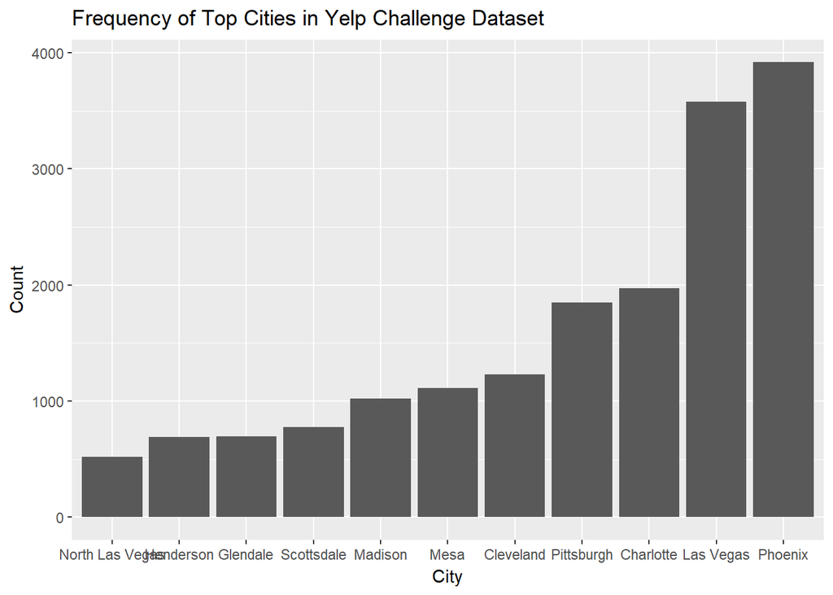

```r
temp <- row.names(as.data.frame(summary(Full_data_long$City, max=12))) # create a df or something else with the summary output.
Full_data_long$City <- as.character(Full_data_long$City) # IMPORTANT! Here was the problem: turn into character values
Full_data_long$top <- ifelse(
  Full_data_long$City %in% temp, ## condition: match aDDs$answer with row.names in summary df
  Full_data_long$City, ## then it should be named as aDDs$answer
  "Other" ## else it should be named "Other"
)
Full_data_long$top <- as.factor(Full_data_long$top) # factorize the output again
ggplot(Full_data_long[Full_data_long$top!="Other",],aes(x=factor(top, levels=names(sort(table(top),increasing=TRUE))))) + geom_bar() + labs(title="Frequency of Top Cities in Yelp Challenge Dataset") + xlab("City") + ylab("Count")
```

This assesses the count of cities in the dataset. Top cities include Phoenix, Las Vegas, Charlotte, Pittsburgh, Cleveland.

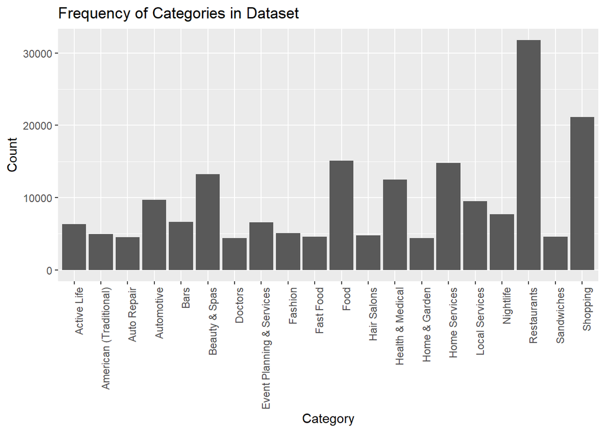

```r
# Reformat data to suit plot
catplot <- business_zillow%>%select(-starts_with("hours"), -starts_with("attribute")) %>% unnest(categories) %>%
  select(name, categories)%>%group_by(categories)%>%summarise(n=n())%>%arrange(desc(n))%>%head(20)
catplot <- as.data.frame(catplot)

ggplot(data=catplot, aes(x=categories, y=n)) +
  geom_bar(stat="identity") + theme(axis.text.x = element_text(angle = 90, hjust = 1)) + labs(title="Frequency of Categories in Dataset") + xlab("Category") + ylab("Count")
```

This counts the “cateories” included in the dataset. These categories are tags users might use to describe various businesses. We can see that the top category is “Restuarants” followed by “Shopping,” “Food,” “Home Services,” and “Beauty and Spa.”

The Yelp dataset includes information on businesses that may have been open but are currently closed. The previous analyses included all of them, but here we assess the counts of categories only for buinesses that are open.

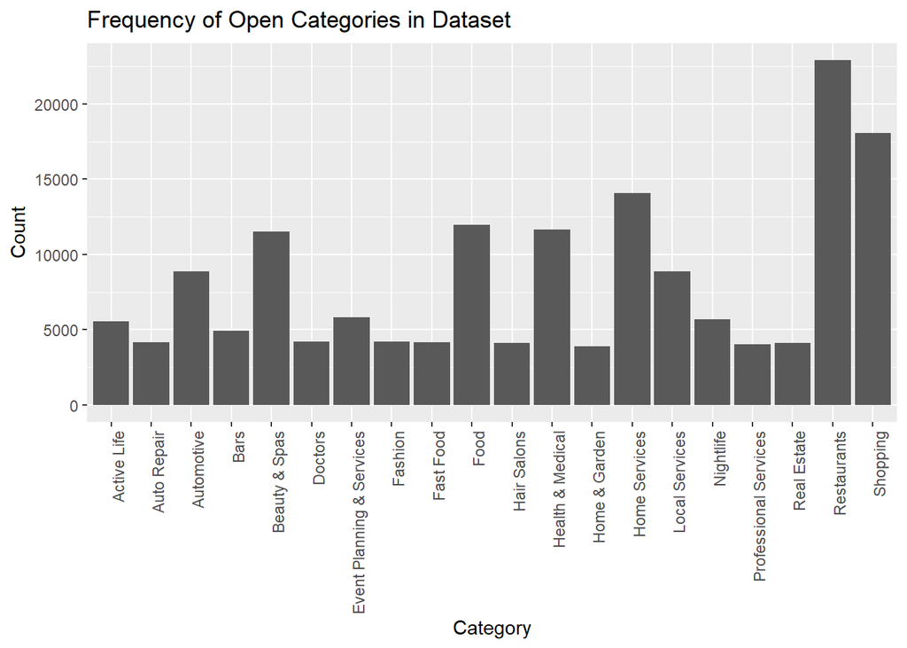

```r
catplot_open <- business_zillow %>%
  select(-starts_with("hours"), -starts_with("attribute")) %>%
  filter(is_open==1) %>%
  unnest(categories) %>%
  select(name, categories) %>%
  group_by(categories) %>%
  summarise(n=n()) %>%
  arrange(desc(n)) %>%
  head(20)

catplot_open  <- as.data.frame(catplot_open )

ggplot(data=catplot_open , aes(x=categories, y=n)) +
  geom_bar(stat="identity") + theme(axis.text.x = element_text(angle = 90, hjust = 1)) + labs(title="Frequency of Open Categories in Dataset") + xlab("Category") + ylab("Count")
```

Top categories include: Restaurants, Shopping, Home Services, Food, Health & Medical. Interestingly, it seems like “Food” and “Beauty & Spas” might be closing at higher rate than other categories.

Now, we compare the rent prices across cities. We use cities as categorizing variable because there are far too many zip codes in the dataset.

```r
# Reimport data for plotting
zillow <- read_csv("zecon/Zip_Zri_AllHomesPlusMultifamily.csv", col_names = TRUE)
# Eliminate unneeded columns
zillow <- zillow[-c(94:95)]

# Convert from long to wide by city
zillow_collapse_wide <- zillow %>%
  group_by(City) %>%
  summarize_all(funs(mean))
names(zillow_long)
```

```
##  [1] "RegionID"    "postal_code" "City"        "State"       "Metro"
##  [6] "CountyName"  "SizeRank"    "time"        "rentprice"   "month"
## [11] "year"        "YearMonth"
```

```r
# Collapse to long by State and time period.
zillow_collapse_long <- zillow_long %>%
  group_by(State, time) %>%
  summarize(rentprice = mean(rentprice))
```

Finally, we compose a graph illustrating rents over time

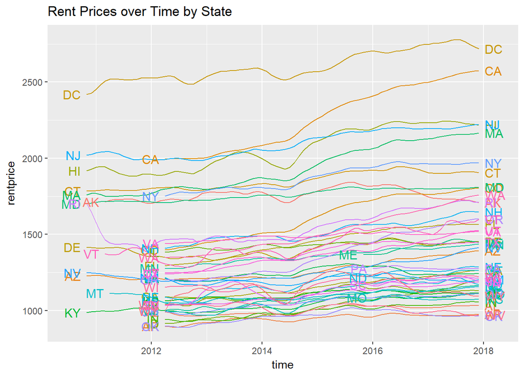

```r
ggplot(zillow_collapse_long, aes(x = time, y=rentprice, group = State, colour = State)) + geom_line()  + scale_colour_discrete(guide = 'none')  + scale_x_date(expand=c(0.1, 0)) + geom_dl(aes(label = State), method = list(dl.trans(x = x + .2), "last.points")) + geom_dl(aes(label = State), method = list(dl.trans(x = x - .2), "first.points")) + labs(title = "Rent Prices over Time by State", xlab = "Rent Price (USD)")
```

Few states in the dataset appear to have experienced overall declines in rent over the periods in question. California, Oregon, Colorado, Massachussets, and Washington appear to have experienced significant increases over the time period. DC, California, New Jersey, Hawaii, and Massachussets are consistently plagued by high rents prices.

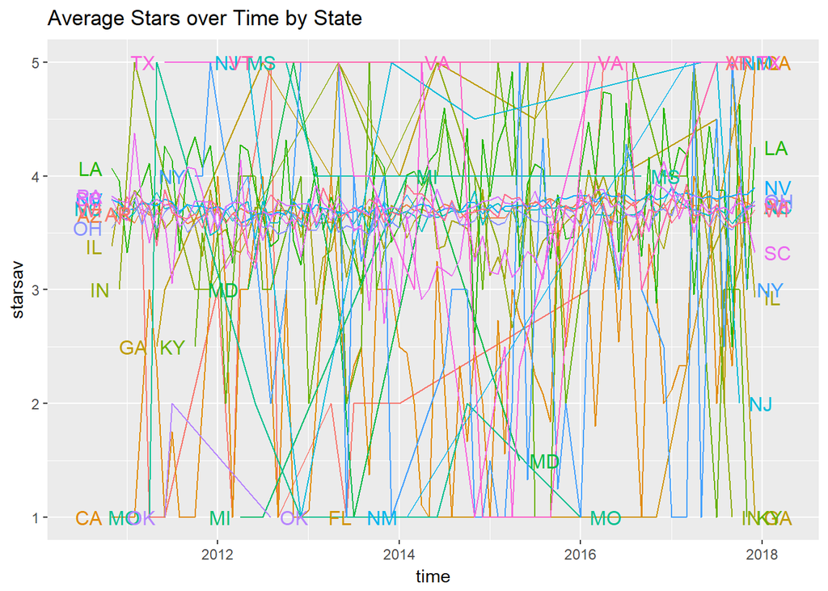

```r
# First, we collapse by state
FDL_collapse_long <- Full_data_long %>%
  group_by(State, time) %>%
  summarize(starsav = mean(starsav))

ggplot(FDL_collapse_long, aes(x = time, y=starsav, group = State, colour = State)) + geom_line()  + scale_colour_discrete(guide = 'none')  + scale_x_date(expand=c(0.1, 0)) + geom_dl(aes(label = State), method = list(dl.trans(x = x + .2), "last.points")) +
  geom_dl(aes(label = State), method = list(dl.trans(x = x - .2), "first.points")) + labs(title = "Average Stars over Time by State", xlab = "Avg. Stars (1-5)")
```

As we can see, there don’t appear to be any trends or patterns. Seems like a very random relationship.

## Modeling and Panel Data Regression Analysis

Now comes the fun part. We split the data into train and test sets where our test set comprises the last year (12 months) of our data set. We run a Hausman test to determine whether we should run a fixed effects (“within”) or a random effects model. Then we develop a Panel Linear Regression model to predict housing prices.

```r
# Create test and train
Full_data_long_train <- Full_data_long[Full_data_long$time < "2017-01-01",]
Full_data_long_test <- Full_data_long[Full_data_long$time >= "2017-01-01",]

# Set parameters
my.formula <- rentprice ~ starsav + is_openave + funnyav + coolav + usefulav
my.index <- c('postal_code','time')

# Conduct test
my.hausman.test.train <- phtest(x = my.formula,
                          data = Full_data_long_train,
                          model = c('within', 'random'),
                          index = my.index)
print(my.hausman.test.train)
```

```
##
##  Hausman Test
##
## data:  my.formula
## chisq = 1.2796, df = 5, p-value = 0.937
## alternative hypothesis: one model is inconsistent
```

The high p-value of 0.937 indicates that we should use a random effects model instead of a fixed effects model.

Now, we build our random effects model on the training dataset and predict on the test set. We calculate the Mean Averege Percent Error (MAPE) to see how accurately our model uses training values to predict rental prices in the test set.

```r
my.pdm.train <- plm(data = Full_data_long_train,
              formula = my.formula,
              model = 'random',
              index = my.index)
summary(my.pdm.train)
```

```
## Oneway (individual) effect Random Effect Model
##    (Swamy-Arora's transformation)
##
## Call:
## plm(formula = my.formula, data = Full_data_long_train, model = "random",
##     index = my.index)
##
## Unbalanced Panel: n = 560, T = 1-74, N = 31397
##
## Effects:
##                     var   std.dev share
## idiosyncratic   6321.76     79.51 0.023
## individual    270893.25    520.47 0.977
## theta:
##    Min. 1st Qu.  Median    Mean 3rd Qu.    Max.
##  0.8490  0.9817  0.9822  0.9806  0.9822  0.9822
##
## Residuals:
##     Min.  1st Qu.   Median     Mean  3rd Qu.     Max.
## -2126.91   -40.27    -6.88    -0.36    37.76  2068.60
##
## Coefficients:
##               Estimate Std. Error  t-value  Pr(>|t|)
## (Intercept) 1238.62701   22.65028  54.6848 < 2.2e-16 ***
## starsav       -2.85126    0.83058  -3.4329  0.000598 ***
## is_openave   131.20358    3.13631  41.8337 < 2.2e-16 ***
## funnyav      -10.17243    0.86013 -11.8266 < 2.2e-16 ***
## coolav        11.10536    0.96571  11.4997 < 2.2e-16 ***
## usefulav     -11.10133    0.42243 -26.2800 < 2.2e-16 ***
## ---
## Signif. codes:  0 '***' 0.001 '**' 0.01 '*' 0.05 '.' 0.1 ' ' 1
##
## Total Sum of Squares:    226790000
## Residual Sum of Squares: 203110000
## R-Squared:      0.10443
## Adj. R-Squared: 0.10429
## F-statistic: 731.838 on 5 and 31391 DF, p-value: < 2.22e-16
```

```r
Full_data_long_test$pred.plm.test <- predict(my.pdm.train, Full_data_long_test, type='response')

plmmape <- 100*mean(abs(Full_data_long_test$pred.plm.test/Full_data_long_test$rentprice-1), na.rm = T)
print(plmmape)
```

```
## [1] 21.39346
```

MAPE is only 21.39% right now. We will continue working on the model to get this error lower.

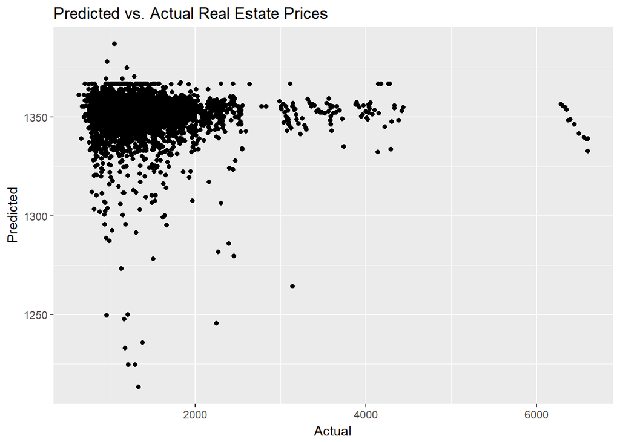

```r
ggplot(Full_data_long_test, aes(x=rentprice, y=pred.plm.test)) +geom_point() + labs(title="Predicted vs. Actual Real Estate Prices") + xlab("Actual") + ylab("Predicted")
```

The plot above shows a significant discrepency existing between actual and predicted rent prices.

## Generating the Lag Model

To fine-tune the model, we decide to lag the dependent variable to consider the possibility that last month’s rent could be the best predictor of this month’s rent price. We follow a similar process to the one above for training, testing, and predicting.

```r
my.lag.formula <- rentprice ~ lag(rentprice, 1) + starsav + is_openave + funnyav + coolav + usefulav + Number_of_reviews

# Conduct Hausman Test
my.hausman.test.train.lag <- phtest(x = my.lag.formula,
                                data = Full_data_long_train,
                                model = c('within', 'random'),
                                index = my.index)

# print result
print(my.hausman.test.train.lag)
```

```
##
##  Hausman Test
##
## data:  my.lag.formula
## chisq = 289.55, df = 7, p-value < 2.2e-16
## alternative hypothesis: one model is inconsistent
```

Then, we build the model on the training set and predict on the test set in order to calculate the MAPE.

```r
my.pdm.train.lag <- plm(data = Full_data_long_train,
                    formula = my.lag.formula,
                    model = 'random',
                    index = my.index)
summary(my.pdm.train.lag)
```

```
## Oneway (individual) effect Random Effect Model
##    (Swamy-Arora's transformation)
##
## Call:
## plm(formula = my.lag.formula, data = Full_data_long_train, model = "random",
##     index = my.index)
##
## Unbalanced Panel: n = 519, T = 1-73, N = 29252
##
## Effects:
##                   var std.dev share
## idiosyncratic 161.483  12.708 0.993
## individual      1.107   1.052 0.007
## theta:
##    Min. 1st Qu.  Median    Mean 3rd Qu.    Max.
## 0.00341 0.17795 0.18361 0.17177 0.18361 0.18361
##
## Residuals:
##     Min.  1st Qu.   Median     Mean  3rd Qu.     Max.
## -142.410   -4.848    0.001    0.009    5.213  132.569
##
## Coefficients:
##                      Estimate  Std. Error   t-value  Pr(>|t|)
## (Intercept)       -0.81953342  0.73031005   -1.1222  0.261799
## lag(rentprice, 1)  1.00093673  0.00017581 5693.3592 < 2.2e-16 ***
## starsav           -0.25238363  0.14094489   -1.7907  0.073359 .
## is_openave         3.34976459  0.48784817    6.8664 6.715e-12 ***
## funnyav           -0.49065915  0.15640230   -3.1372  0.001708 **
## coolav            -0.01465219  0.16578108   -0.0884  0.929573
## usefulav          -0.19242788  0.07260164   -2.6505  0.008043 **
## Number_of_reviews  0.00124545  0.00029642    4.2016 2.659e-05 ***
## ---
## Signif. codes:  0 '***' 0.001 '**' 0.01 '*' 0.05 '.' 0.1 ' ' 1
##
## Total Sum of Squares:    5351700000
## Residual Sum of Squares: 4771300
## R-Squared:      0.99911
## Adj. R-Squared: 0.99911
## F-statistic: 4681730 on 7 and 29244 DF, p-value: < 2.22e-16
```

```r
# Predict
Full_data_long_test$pred.plm.test.lag <- predict(my.pdm.train.lag, Full_data_long_test, type='response')

# MAPE
plmmape.lag <- 100*mean(abs(Full_data_long_test$pred.plm.test.lag/Full_data_long_test$rentprice-1), na.rm = T)
print(plmmape.lag)
```

```
## [1] 0.2112457
```

Now we get a MAPE of 0.211, far lower than the non-lagged model. This supports the hypothesis that last month’s rent could be the best predictor of this month’s rent price.

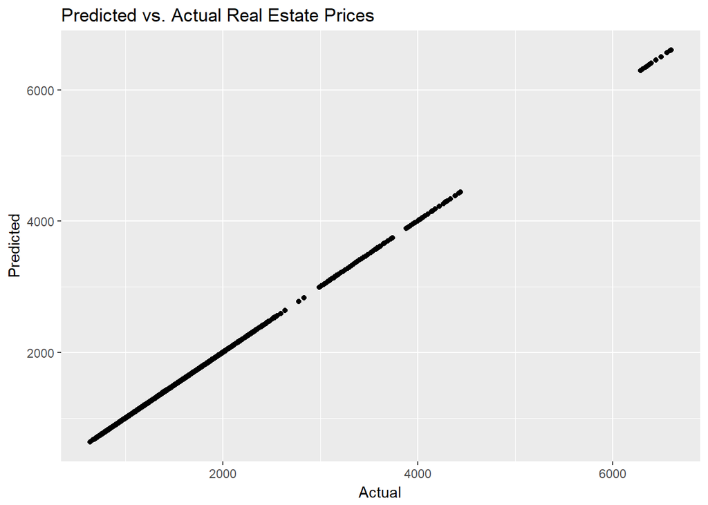

```r
ggplot(Full_data_long_test, aes(x=rentprice, y=pred.plm.test.lag)) +geom_point() + labs(title="Predicted vs. Actual Real Estate Prices") + xlab("Actual") + ylab("Predicted")
```

## Multiple Imputation for Missing Values Using the Amelia Package

This process uses bootstrapping and Expectation-Maximization algorithm to impute the missing values in a data set. In our model, we will be able to throw in almost all of our independent variables.

```r
# Look at missingness to get a sense of what needs to be imputed.
sapply(Full_data_long, function(x) sum(is.na(x)))
```

```
##                    X          postal_code            YearMonth
##                    0                    0                    0
## Number_of_businesses    Number_of_reviews              starsav
##                    0                    0                    0
##              starssd             usefulav              funnyav
##                 2977                    0                    0
##               coolav             bizstars           bizstarssd
##                    0                    0                 2977
##          bizrevcount             bizrevav           is_openave
##                    0                    0                    0
##           Friday_ave           Monday_ave         Saturday_ave
##                 1337                 1337                 1337
##           Sunday_ave         Thursday_ave          Tuesday_ave
##                 1337                 1337                 1337
##        Wednesday_ave         Friday_total         Monday_total
##                 1337                 1337                 1337
##       Saturday_total         Sunday_total       Thursday_total
##                 1337                 1337                 1337
##        Tuesday_total      Wednesday_total             RegionID
##                 1337                 1337                    0
##                 City                State                Metro
##                    0                    0                   64
##           CountyName             SizeRank                 time
##                    0                    0                    0
##            rentprice                month                 year
##                  580                    0                    0
##                  top
##                    0
```

```r
Full_data_long <- Full_data_long[-c(40)]
Imputed_Full_data_long <-amelia(Full_data_long,ts= 'time', cs= 'postal_code', p2s=0, intercs = FALSE, idvars=c('City', 'State', 'Metro', 'CountyName', 'year', 'month', 'YearMonth'))

write.amelia(obj=Imputed_Full_data_long, file.stem="imputedfull")

data1 <- read.csv("imputedfull1.csv")
data2 <- read.csv("imputedfull2.csv")
data3 <- read.csv("imputedfull3.csv")
data4 <- read.csv("imputedfull4.csv")
data5 <- read.csv("imputedfull5.csv")

data1 <- pdata.frame(data1, index = c("postal_code", "time"))
data2 <- pdata.frame(data2, index = c("postal_code", "time"))
data3 <- pdata.frame(data3, index = c("postal_code", "time"))
data4 <- pdata.frame(data4, index = c("postal_code", "time"))
data5 <- pdata.frame(data5, index = c("postal_code", "time"))

allimp <- imputationList(list(data1,data2,data3,data4,data5))
```

Now, we will create the train and tests set using the last 12 months (1 year) for the test set, but with imputed values from an Amelia imputation iteration.

```r
data5$time <- as.Date(data5$time, "%Y-%m-%d")
data5_train <- data5[data5$time < "2017-01-01",]
data5_test <- data5[data5$time >= "2017-01-01",]

my.formula.impute.lag <- rentprice ~ lag(rentprice, 12) + starsav + starssd + is_openave + funnyav + coolav + usefulav + Number_of_reviews + Number_of_businesses + Friday_ave + Monday_ave + Saturday_ave + Sunday_ave + Thursday_ave + Tuesday_ave + Wednesday_ave + Friday_total + Monday_total + Saturday_total + Sunday_total + Thursday_total + Tuesday_total + Wednesday_total

my.index <- c('postal_code','time')

# Conduct Hausman Test
my.hausman.test.train.impute.lag <- phtest(x = my.formula.impute.lag,
                                           data = data5_train,
                                           model = c('within', 'random'),
                                           index = my.index)
# print result
print(my.hausman.test.train.impute.lag)
```

```
##
##  Hausman Test
##
## data:  my.formula.impute.lag
## chisq = 26949, df = 23, p-value < 2.2e-16
## alternative hypothesis: one model is inconsistent
```

Build random effects model on train and predict on test.

```r
my.pdm.train.impute.lag <- plm(data = data5_train,
                    formula = my.formula.impute.lag,
                    model = 'random',
                    index = my.index)
summary(my.pdm.train.impute.lag)
```

```
## Oneway (individual) effect Random Effect Model
##    (Swamy-Arora's transformation)
##
## Call:
## plm(formula = my.formula.impute.lag, data = data5_train, model = "random",
##     index = my.index)
##
## Unbalanced Panel: n = 425, T = 1-62, N = 22754
##
## Effects:
##                   var std.dev share
## idiosyncratic 4865.68   69.75  0.91
## individual     482.95   21.98  0.09
## theta:
##    Min. 1st Qu.  Median    Mean 3rd Qu.    Max.
## 0.04622 0.62612 0.62612 0.61172 0.62612 0.62612
##
## Residuals:
##     Min.  1st Qu.   Median     Mean  3rd Qu.     Max.
## -1549.77   -31.94    -6.88     0.13    22.53  1691.40
##
## Coefficients:
##                         Estimate  Std. Error  t-value  Pr(>|t|)
## (Intercept)          131.7341705  13.2088340   9.9732 < 2.2e-16 ***
## lag(rentprice, 12)     0.8541850   0.0030900 276.4392 < 2.2e-16 ***
## starsav                3.7377631   2.0688238   1.8067 0.0708208 .
## starssd                6.6399122   2.8869619   2.3000 0.0214592 *
## is_openave            52.5476146   6.2974851   8.3442 < 2.2e-16 ***
## funnyav               -3.3460268   2.0067289  -1.6674 0.0954480 .
## coolav                 2.0236510   1.9136960   1.0575 0.2903144
## usefulav              -4.9908304   0.8901207  -5.6069 2.084e-08 ***
## Number_of_reviews     -0.0073606   0.0102732  -0.7165 0.4736952
## Number_of_businesses   0.4590291   0.0430771  10.6560 < 2.2e-16 ***
## Friday_ave           -25.8451923   9.2396927  -2.7972 0.0051592 **
## Monday_ave           -10.8947115   7.5300576  -1.4468 0.1479584
## Saturday_ave           7.4059539   6.3548312   1.1654 0.2438672
## Sunday_ave             9.9146898   5.8711697   1.6887 0.0912892 .
## Thursday_ave          13.9598852   9.4181020   1.4822 0.1382904
## Tuesday_ave          -19.9316302  10.6355820  -1.8741 0.0609361 .
## Wednesday_ave         31.4402288  10.7728562   2.9185 0.0035210 **
## Friday_total           0.0219276   0.0047143   4.6512 3.318e-06 ***
## Monday_total          -0.0213114   0.0041126  -5.1819 2.215e-07 ***
## Saturday_total        -0.0224851   0.0038506  -5.8393 5.313e-09 ***
## Sunday_total           0.0204787   0.0035282   5.8043 6.548e-09 ***
## Thursday_total         0.0015014   0.0073728   0.2036 0.8386392
## Tuesday_total          0.0252178   0.0098594   2.5577 0.0105419 *
## Wednesday_total       -0.0293251   0.0087719  -3.3431 0.0008299 ***
## ---
## Signif. codes:  0 '***' 0.001 '**' 0.01 '*' 0.05 '.' 0.1 ' ' 1
##
## Total Sum of Squares:    1069300000
## Residual Sum of Squares: 212010000
## R-Squared:      0.80173
## Adj. R-Squared: 0.80153
## F-statistic: 3996.19 on 23 and 22730 DF, p-value: < 2.22e-16
```

```r
data5_test$pred.plm.test.impute.lag <- predict(my.pdm.train.impute.lag, data5_test, type='response')

plmmape_impute_lag <- 100*mean(abs(data5_test$pred.plm.test.impute.lag/data5_test$rentprice-1), na.rm = T)
print(plmmape_impute_lag)
```

```
## [1] 4.832758
```

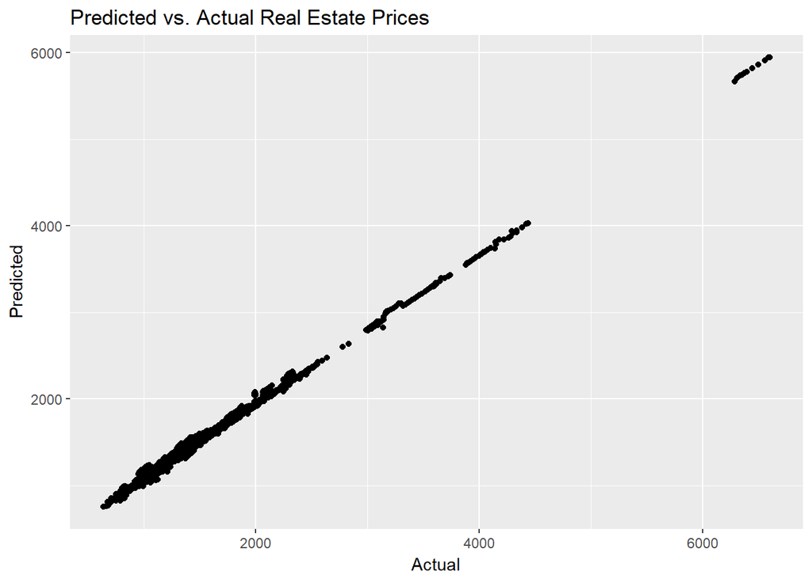

```r
ggplot(data5_test, aes(x=rentprice, y=pred.plm.test.impute.lag)) + geom_point() + labs(title="Predicted vs. Actual Real Estate Prices") + xlab("Actual") + ylab("Predicted")
```

Now, we conduct a reduced imputed model, which excludes checkin data

```r
my.formula.impute.lag.Simple <- rentprice ~ lag(rentprice, 12) + starsav + starssd + is_openave + funnyav + coolav + usefulav + Number_of_reviews + Number_of_businesses
my.index <- c('postal_code','time')

my.hausman.test.train.impute.lag.Simple <- phtest(x = my.formula.impute.lag.Simple,
                                                  data = data5_train,
                                                  model = c('within', 'random'),
                                                  index = my.index)

print(my.hausman.test.train.impute.lag.Simple)
```

```
##
##  Hausman Test
##
## data:  my.formula.impute.lag.Simple
## chisq = 27438, df = 9, p-value < 2.2e-16
## alternative hypothesis: one model is inconsistent
```

Build random effects model on train and predict on test

```r
my.pdm.train.impute.lag.Simple <- plm(data = data5_train,
                               formula = my.formula.impute.lag.Simple,
                               model = 'random',
                               index = my.index)
summary(my.pdm.train.impute.lag.Simple)
```

```
## Oneway (individual) effect Random Effect Model
##    (Swamy-Arora's transformation)
##
## Call:
## plm(formula = my.formula.impute.lag.Simple, data = data5_train,
##     model = "random", index = my.index)
##
## Unbalanced Panel: n = 425, T = 1-62, N = 22754
##
## Effects:
##                   var std.dev share
## idiosyncratic 4864.14   69.74 0.909
## individual     486.14   22.05 0.091
## theta:
##    Min. 1st Qu.  Median    Mean 3rd Qu.    Max.
## 0.04651 0.62723 0.62723 0.61284 0.62723 0.62723
##
## Residuals:
##     Min.  1st Qu.   Median     Mean  3rd Qu.     Max.
## -1551.69   -32.20    -7.70     0.09    22.66  1696.24
##
## Coefficients:
##                         Estimate  Std. Error  t-value  Pr(>|t|)
## (Intercept)          111.6803791  11.9521895   9.3439 < 2.2e-16 ***
## lag(rentprice, 12)     0.8614407   0.0030444 282.9614 < 2.2e-16 ***
## starsav                5.6043371   2.0715024   2.7054 0.0068264 **
## starssd               10.2514101   2.8802425   3.5592 0.0003727 ***
## is_openave            67.1850783   6.1750236  10.8801 < 2.2e-16 ***
## funnyav               -4.0904035   2.0147337  -2.0302 0.0423432 *
## coolav                 2.5472141   1.9212403   1.3258 0.1849135
## usefulav              -5.7450344   0.8913600  -6.4452 1.177e-10 ***
## Number_of_reviews     -0.0203698   0.0081892  -2.4874 0.0128753 *
## Number_of_businesses   0.2845879   0.0350684   8.1152 5.092e-16 ***
## ---
## Signif. codes:  0 '***' 0.001 '**' 0.01 '*' 0.05 '.' 0.1 ' ' 1
##
## Total Sum of Squares:    1064400000
## Residual Sum of Squares: 214270000
## R-Squared:      0.79869
## Adj. R-Squared: 0.79861
## F-statistic: 10026.3 on 9 and 22744 DF, p-value: < 2.22e-16
```

```r
# Predict
data5_test$pred.plm.test.impute.lag.Simple <- predict(my.pdm.train.impute.lag.Simple, data5_test, type='response')

plmmape_impute_lag.Simple <- 100*mean(abs(data5_test$pred.plm.test.impute.lag.Simple/data5_test$rentprice-1), na.rm = T)
print(plmmape_impute_lag.Simple)
```

```
## [1] 4.703226
```